# Linear Model: Cheese Production

For the cheese producers, the profitability is the relation between the weight of the cheese and the amount of milk used to produce it. One is interested in analyzing if the type of milk used changes the profit.

**Three milk types** are considered: **cow, sheep and goat**. For each milk type, one is interested in comparing the profit as a function of the **thermic milk treatment** (plane or pasteurized) and the presence of a given **additive** denoted by CaCl2.
$$profit = g(milk)_{THERMIC \circ CaCl_2} \rightarrow profit \sim THERMIC + CaCl_2 + THERMIC \cdot CaCl_2$$

$$\rightarrow profit \sim THERMIC *CaCl_2$$
a) Assuming that the ANOVA conditions are satisfied, for each type of milk answer the following questions and justify your answer:  Which treatment is the best?  The addition of CaCl2 does it increase the rendibility?  Does the thermic treatment increase the rendibility? b) Do you think that the ANOVA hypothesis are verified? Answer this question theoretically and by means of diagnosis techniques.

Llet crua o pasteuritzada Afegir Clorur calcic o no. Son els dos factors. Quina combinacio es millor: crua amb clorur o qualsevol altra comb.

```r
dd<-read.csv2("cheese.csv")

library(car)
library(emmeans)
library(tables)
#library("RcmdrMisc")
```

```r
is.factor(dd$COW)
```

```
## [1] FALSE
```

```r
tabular(COW*(THERMIC=1)~((CaCl2)*mean), dd)
```

|  |  | CaCl2 no mean | CaCl2 yes mean |
| --- | --- | --- | --- |
| COW | THERMIC | 54.55 | 42.9 |

```r
tabular(COW*(THERMIC=1)~((CaCl2)*sd), dd)
```

|  |  | CaCl2 no sd | CaCl2 yes sd |
| --- | --- | --- | --- |
| COW | THERMIC | 5.662 | 5.389 |

```r
tabular(COW*(THERMIC=1)~((CaCl2)*(n=1)), dd)
```

|  |  | CaCl2 no n | CaCl2 yes n |
| --- | --- | --- | --- |
| COW | THERMIC | 8 | 8 |

```r
tabular(COW*(THERMIC+1)~((CaCl2+1)*mean), dd)
```

|  | THERMIC | CaCl2 no mean | CaCl2 yes mean | All mean |
| --- | --- | --- | --- | --- |
| COW | pasteurized | 50.54 | 46.00 | 48.27 |
|  | plane | 58.56 | 39.81 | 49.19 |
|  | All | 54.55 | 42.90 | 48.73 |

```r
summary(mc<-lm(COW~THERMIC*CaCl2, dd))
```

```
##
## Call:
## lm(formula = COW ~ THERMIC * CaCl2, data = dd)
##
## Residuals:
##     Min      1Q  Median      3Q     Max
## -5.9850 -3.2138  0.1913  2.5437  7.1513
##
## Coefficients:
##                       Estimate Std. Error t value Pr(>|t|)
## (Intercept)             50.543      2.152  23.484 2.12e-11 ***
## THERMICplane             8.023      3.044   2.636  0.02174 *
## CaCl2yes                -4.542      3.044  -1.492  0.16141
## THERMICplane:CaCl2yes  -14.214      4.304  -3.302  0.00632 **
## ---
## Signif. codes:  0 '***' 0.001 '**' 0.01 '*' 0.05 '.' 0.1 ' ' 1
##
## Residual standard error: 4.304 on 12 degrees of freedom
## Multiple R-squared:  0.7709, Adjusted R-squared:  0.7136
## F-statistic: 13.46 on 3 and 12 DF,  p-value: 0.0003799
```

La grafica de interaccio:

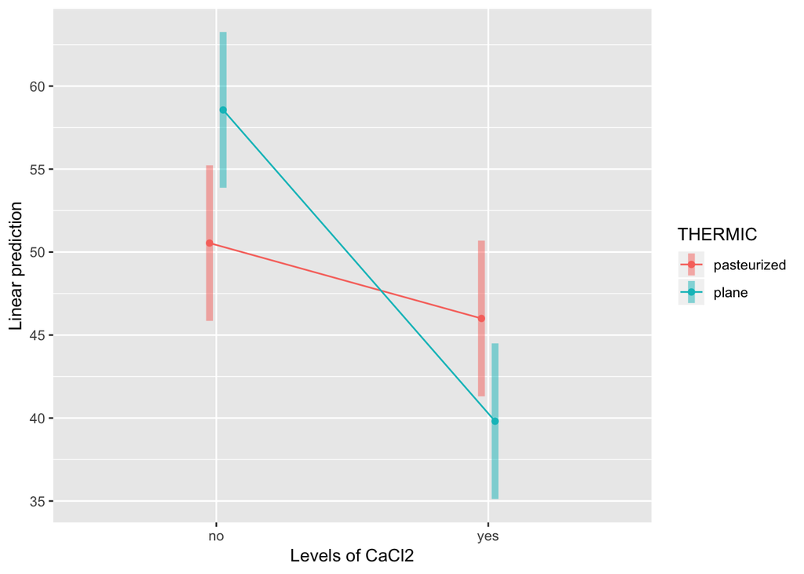

```r
(emmip(mc,THERMIC~CaCl2, CIs = TRUE))
```

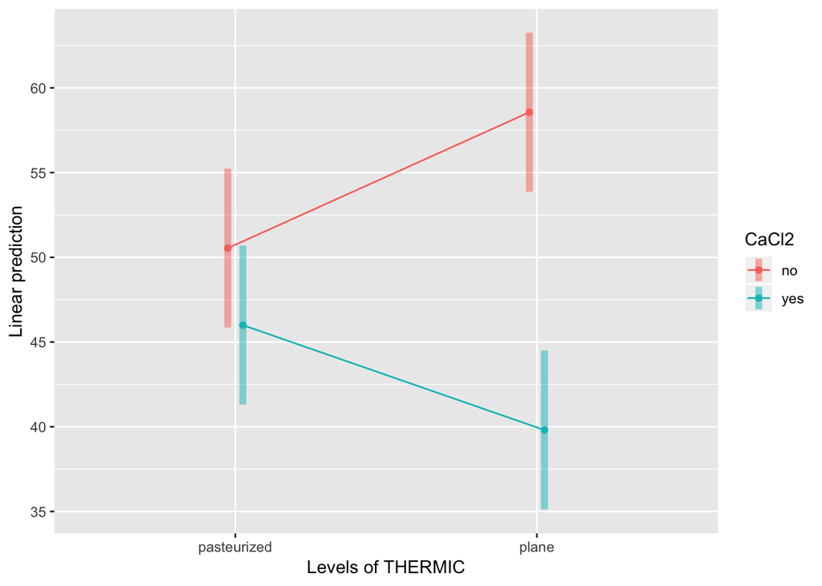

```r
(emmip(mc,CaCl2~THERMIC, CIs = TRUE))
```

fem lanova per saber de qui es l’efecte:

```r
Anova(mc)
```

```
## Anova Table (Type II tests)
##
## Response: COW
##               Sum Sq Df F value    Pr(>F)
## THERMIC         3.35  1   0.181 0.6780528
## CaCl2         542.83  1  29.297 0.0001568 ***
## THERMIC:CaCl2 202.03  1  10.904 0.0063162 **
## Residuals     222.34 12
## ---
## Signif. codes:  0 '***' 0.001 '**' 0.01 '*' 0.05 '.' 0.1 ' ' 1
```

THERMIC no afecta en lefecte principal pero si en la interaccio. Per saber quina combinacio millor

```r
(emm<-emmeans(mc,~THERMIC*CaCl2))
```

```
##  THERMIC     CaCl2   emmean       SE df lower.CL upper.CL
##  pasteurized no    50.54250 2.152232 12 45.85319 55.23181
##  plane       no    58.56500 2.152232 12 53.87569 63.25431
##  pasteurized yes   46.00000 2.152232 12 41.31069 50.68931
##  plane       yes   39.80875 2.152232 12 35.11944 44.49806
##
## Confidence level used: 0.95
```

```r
CLD(emm,Letters=letters, reversed=T)
```

```
##  THERMIC     CaCl2   emmean       SE df lower.CL upper.CL .group
##  plane       no    58.56500 2.152232 12 53.87569 63.25431  a
##  pasteurized no    50.54250 2.152232 12 45.85319 55.23181  ab
##  pasteurized yes   46.00000 2.152232 12 41.31069 50.68931   bc
##  plane       yes   39.80875 2.152232 12 35.11944 44.49806    c
##
## Confidence level used: 0.95
## P value adjustment: tukey method for comparing a family of 4 estimates
## significance level used: alpha = 0.05
```

Potser es millor mirar condicionant si podem clorur(o no per cada tractamnet termic). Es una forma mes resumida:

```r
(emm<-emmeans(mc,~THERMIC|CaCl2))
```

```
## CaCl2 = no:
##  THERMIC       emmean       SE df lower.CL upper.CL
##  pasteurized 50.54250 2.152232 12 45.85319 55.23181
##  plane       58.56500 2.152232 12 53.87569 63.25431
##
## CaCl2 = yes:
##  THERMIC       emmean       SE df lower.CL upper.CL
##  pasteurized 46.00000 2.152232 12 41.31069 50.68931
##  plane       39.80875 2.152232 12 35.11944 44.49806
##
## Confidence level used: 0.95
```

```r
CLD(emm,Letters=letters, reversed=T)
```

```
## CaCl2 = no:
##  THERMIC       emmean       SE df lower.CL upper.CL .group
##  plane       58.56500 2.152232 12 53.87569 63.25431  a
##  pasteurized 50.54250 2.152232 12 45.85319 55.23181   b
##
## CaCl2 = yes:
##  THERMIC       emmean       SE df lower.CL upper.CL .group
##  pasteurized 46.00000 2.152232 12 41.31069 50.68931  a
##  plane       39.80875 2.152232 12 35.11944 44.49806  a
##
## Confidence level used: 0.95
## significance level used: alpha = 0.05
```

(emm<-emmeans(mcol,~THERMIC))

No podem fer aixo!! pot ser fals!! (emm<-emmeans(mcol,~CaCl2))

(emm<-emmeans(mcol,~CaCl2 barra THERMIC))

Diagnostics

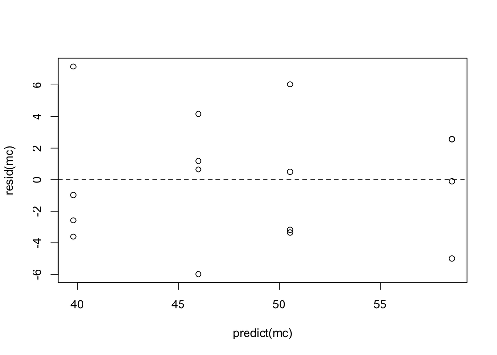

```r
plot(predict(mc), resid(mc))
abline(h=0, lty=2)
```

El model factorial

```r
summary(mgoat<-lm(GOAT~THERMIC*CaCl2, dd))
```

```
##
## Call:
## lm(formula = GOAT ~ THERMIC * CaCl2, data = dd)
##
## Residuals:
##     Min      1Q  Median      3Q     Max
## -6.3275 -2.1966 -0.5594  2.1475  9.6175
##
## Coefficients:
##                       Estimate Std. Error t value Pr(>|t|)
## (Intercept)             49.570      2.195  22.587 3.36e-11 ***
## THERMICplane            -7.220      3.104  -2.326   0.0383 *
## CaCl2yes                -6.339      3.104  -2.042   0.0637 .
## THERMICplane:CaCl2yes    4.936      4.389   1.125   0.2827
## ---
## Signif. codes:  0 '***' 0.001 '**' 0.01 '*' 0.05 '.' 0.1 ' ' 1
##
## Residual standard error: 4.389 on 12 degrees of freedom
## Multiple R-squared:  0.4303, Adjusted R-squared:  0.2879
## F-statistic: 3.021 on 3 and 12 DF,  p-value: 0.07157
```

El model additiu

```r
summary(mgoat2<-lm(GOAT~THERMIC+CaCl2, dd))
```

```
##
## Call:
## lm(formula = GOAT ~ THERMIC + CaCl2, data = dd)
##
## Residuals:
##     Min      1Q  Median      3Q     Max
## -6.5691 -2.3466 -0.3225  1.6197 10.8516
##
## Coefficients:
##              Estimate Std. Error t value Pr(>|t|)
## (Intercept)    48.336      1.920  25.177 2.05e-12 ***
## THERMICplane   -4.752      2.217  -2.143   0.0516 .
## CaCl2yes       -3.871      2.217  -1.746   0.1044
## ---
## Signif. codes:  0 '***' 0.001 '**' 0.01 '*' 0.05 '.' 0.1 ' ' 1
##
## Residual standard error: 4.434 on 13 degrees of freedom
## Multiple R-squared:  0.3702, Adjusted R-squared:  0.2734
## F-statistic: 3.822 on 2 and 13 DF,  p-value: 0.0495
```

```r
Anova(mgoat2)
```

```
## Anova Table (Type II tests)
##
## Response: GOAT
##            Sum Sq Df F value  Pr(>F)
## THERMIC    90.321  1  4.5946 0.05156 .
## CaCl2      59.927  1  3.0485 0.10439
## Residuals 255.556 13
## ---
## Signif. codes:  0 '***' 0.001 '**' 0.01 '*' 0.05 '.' 0.1 ' ' 1
```

El model factorial per l’ovella:

```r
summary(msh<-lm(SHEEP~THERMIC*CaCl2, dd))
```

```
##
## Call:
## lm(formula = SHEEP ~ THERMIC * CaCl2, data = dd)
##
## Residuals:
##     Min      1Q  Median      3Q     Max
## -8.8675 -2.5797 -0.3275  2.0478  9.8775
##
## Coefficients:
##                       Estimate Std. Error t value Pr(>|t|)
## (Intercept)             72.299      2.870  25.193 9.29e-12 ***
## THERMICplane            -5.661      4.059  -1.395    0.188
## CaCl2yes                -6.819      4.059  -1.680    0.119
## THERMICplane:CaCl2yes   -7.294      5.740  -1.271    0.228
## ---
## Signif. codes:  0 '***' 0.001 '**' 0.01 '*' 0.05 '.' 0.1 ' ' 1
##
## Residual standard error: 5.74 on 12 degrees of freedom
## Multiple R-squared:  0.6794, Adjusted R-squared:  0.5993
## F-statistic: 8.478 on 3 and 12 DF,  p-value: 0.002709
```

La variancia del error es el residual standard error al quadrat. La interacci? no dona significativa

```r
anova(msh)
```

```
## Analysis of Variance Table
##
## Response: SHEEP
##               Df Sum Sq Mean Sq F value   Pr(>F)
## THERMIC        1 346.56  346.56 10.5198 0.007042 **
## CaCl2          1 438.12  438.12 13.2988 0.003346 **
## THERMIC:CaCl2  1  53.20   53.20  1.6148 0.227899
## Residuals     12 395.33   32.94
## ---
## Signif. codes:  0 '***' 0.001 '**' 0.01 '*' 0.05 '.' 0.1 ' ' 1
```

Per saber quina combinacio millor

```r
(emmsh<-emmeans(msh,~THERMIC*CaCl2))
```

```
##  THERMIC     CaCl2   emmean      SE df lower.CL upper.CL
##  pasteurized no    72.29875 2.86985 12 66.04588 78.55162
##  plane       no    66.63750 2.86985 12 60.38463 72.89037
##  pasteurized yes   65.48000 2.86985 12 59.22713 71.73287
##  plane       yes   52.52500 2.86985 12 46.27213 58.77787
##
## Confidence level used: 0.95
```

```r
CLD(emmsh,Letters=letters, reversed=T)
```

```
##  THERMIC     CaCl2   emmean      SE df lower.CL upper.CL .group
##  pasteurized no    72.29875 2.86985 12 66.04588 78.55162  a
##  plane       no    66.63750 2.86985 12 60.38463 72.89037  a
##  pasteurized yes   65.48000 2.86985 12 59.22713 71.73287  a
##  plane       yes   52.52500 2.86985 12 46.27213 58.77787   b
##
## Confidence level used: 0.95
## P value adjustment: tukey method for comparing a family of 4 estimates
## significance level used: alpha = 0.05
```

```r
(emmsh<-emmeans(msh,~CaCl2))
```

```
## NOTE: Results may be misleading due to involvement in interactions
```

```
##  CaCl2   emmean      SE df lower.CL upper.CL
##  no    69.46812 2.02929 12 65.04668 73.88957
##  yes   59.00250 2.02929 12 54.58106 63.42394
##
## Results are averaged over the levels of: THERMIC
## Confidence level used: 0.95
```

```r
CLD(emmsh,Letters=letters, reversed=T)
```

```
##  CaCl2   emmean      SE df lower.CL upper.CL .group
##  no    69.46812 2.02929 12 65.04668 73.88957  a
##  yes   59.00250 2.02929 12 54.58106 63.42394   b
##
## Results are averaged over the levels of: THERMIC
## Confidence level used: 0.95
## significance level used: alpha = 0.05
```

El model additiu per l’ovella:

```r
summary(msh2<-lm(SHEEP~THERMIC+CaCl2, dd))
```

```
##
## Call:
## lm(formula = SHEEP ~ THERMIC + CaCl2, data = dd)
##
## Residuals:
##    Min     1Q Median     3Q    Max
## -7.044 -3.181 -1.205  1.437 11.701
##
## Coefficients:
##              Estimate Std. Error t value Pr(>|t|)
## (Intercept)    74.122      2.543  29.142 3.15e-13 ***
## THERMICplane   -9.308      2.937  -3.169  0.00739 **
## CaCl2yes      -10.466      2.937  -3.563  0.00347 **
## ---
## Signif. codes:  0 '***' 0.001 '**' 0.01 '*' 0.05 '.' 0.1 ' ' 1
##
## Residual standard error: 5.874 on 13 degrees of freedom
## Multiple R-squared:  0.6363, Adjusted R-squared:  0.5803
## F-statistic: 11.37 on 2 and 13 DF,  p-value: 0.001396
```

```r
anova(msh2)
```

```
## Analysis of Variance Table
##
## Response: SHEEP
##           Df Sum Sq Mean Sq F value   Pr(>F)
## THERMIC    1 346.56  346.56  10.045 0.007391 **
## CaCl2      1 438.12  438.12  12.698 0.003466 **
## Residuals 13 448.53   34.50
## ---
## Signif. codes:  0 '***' 0.001 '**' 0.01 '*' 0.05 '.' 0.1 ' ' 1
```

```r
(emmsh<-emmeans(msh2,~THERMIC+CaCl2))
```

```
##  THERMIC     CaCl2   emmean       SE df lower.CL upper.CL
##  pasteurized no    74.12219 2.543455 13 68.62739 79.61699
##  plane       no    64.81406 2.543455 13 59.31926 70.30886
##  pasteurized yes   63.65656 2.543455 13 58.16176 69.15136
##  plane       yes   54.34844 2.543455 13 48.85364 59.84324
##
## Confidence level used: 0.95
```

```r
CLD(emmsh,Letters=letters, reversed=T)
```

```
##  THERMIC     CaCl2   emmean       SE df lower.CL upper.CL .group
##  pasteurized no    74.12219 2.543455 13 68.62739 79.61699  a
##  plane       no    64.81406 2.543455 13 59.31926 70.30886   b
##  pasteurized yes   63.65656 2.543455 13 58.16176 69.15136   b
##  plane       yes   54.34844 2.543455 13 48.85364 59.84324    c
##
## Confidence level used: 0.95
## P value adjustment: tukey method for comparing a family of 4 estimates
## significance level used: alpha = 0.05
```

```r
(emmsh<-emmeans(msh2,~THERMIC))
```

```
##  THERMIC       emmean       SE df lower.CL upper.CL
##  pasteurized 68.88937 2.076722 13 64.40289 73.37586
##  plane       59.58125 2.076722 13 55.09476 64.06774
##
## Results are averaged over the levels of: CaCl2
## Confidence level used: 0.95
```

```r
CLD(emmsh,Letters=letters, reversed=T)
```

```
##  THERMIC       emmean       SE df lower.CL upper.CL .group
##  pasteurized 68.88937 2.076722 13 64.40289 73.37586  a
##  plane       59.58125 2.076722 13 55.09476 64.06774   b
##
## Results are averaged over the levels of: CaCl2
## Confidence level used: 0.95
## significance level used: alpha = 0.05
```

```r
(emmsh<-emmeans(msh2,~CaCl2))
```

```
##  CaCl2   emmean       SE df lower.CL upper.CL
##  no    69.46812 2.076722 13 64.98164 73.95461
##  yes   59.00250 2.076722 13 54.51601 63.48899
##
## Results are averaged over the levels of: THERMIC
## Confidence level used: 0.95
```

```r
CLD(emmsh,Letters=letters, reversed=T)
```

```
##  CaCl2   emmean       SE df lower.CL upper.CL .group
##  no    69.46812 2.076722 13 64.98164 73.95461  a
##  yes   59.00250 2.076722 13 54.51601 63.48899   b
##
## Results are averaged over the levels of: THERMIC
## Confidence level used: 0.95
## significance level used: alpha = 0.05
```